# R for Data Science

#### Scale

- **Scale** functions are in the form `scale` + `_` + name of aesthetic + `_` + name of the scale
- Names of aesthetics include: alpha, color, fill, shape, size, x, y, and more
- Names of scales include: continuous, discrete, manual, date, datetime, and more
- The RColorBrewer and viridis packages can be used to change the color of visual objects
- Check out the ggplot2 reference page to explore scales more

**Change Axes Breaks (Ticks)**

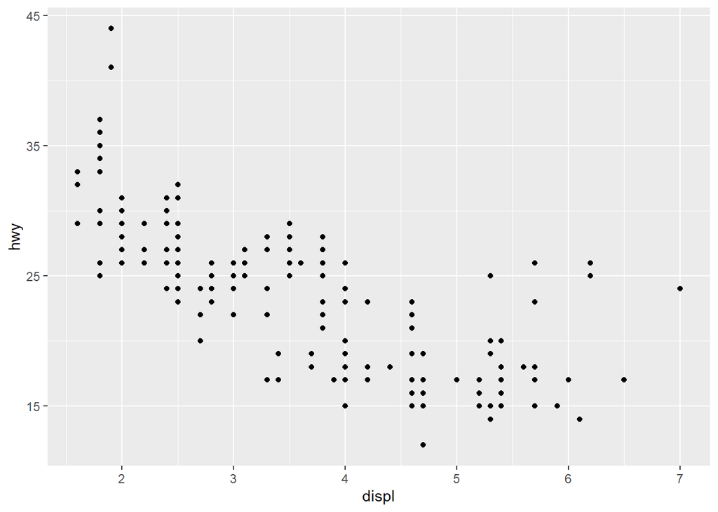

```r
ggplot(data = mpg, mapping = aes(displ, hwy)) +
  geom_point() +
  scale_x_continuous(breaks = seq(0, 7.25, by = 1)) +
  scale_y_continuous(breaks = seq(15, 45, by = 10))
```

**Change Axes Breaks (Ticks) Labels**

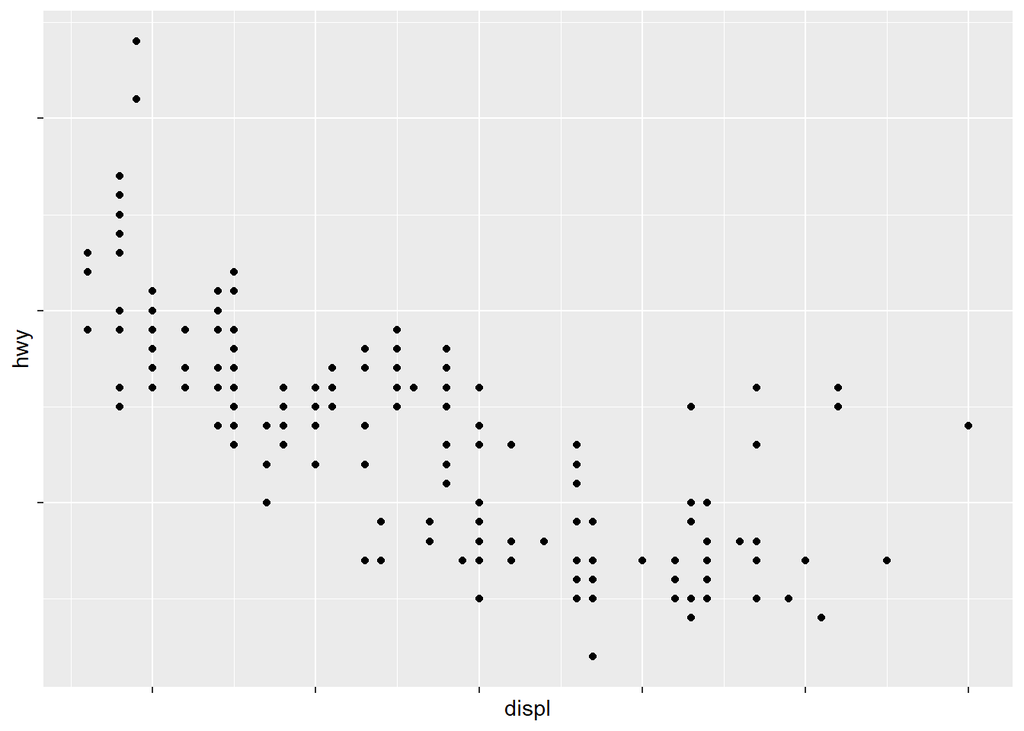

```r
ggplot(data = mpg, mapping = aes(displ, hwy)) +
  geom_point() +
  scale_x_continuous(labels = NULL) +
  scale_y_continuous(labels = NULL)
```

**Change Legend with Theme and Guides**

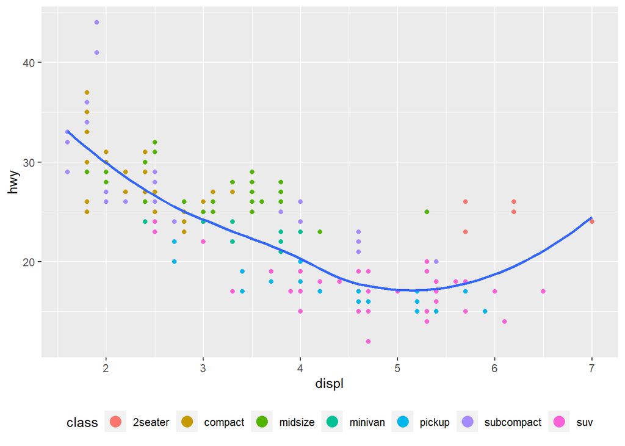

```r
ggplot(mpg, aes(displ, hwy)) +
  geom_point(aes(colour = class)) +
  geom_smooth(se = FALSE) +
  theme(legend.position = "bottom") +
  guides(colour = guide_legend(nrow = 1, override.aes = list(size = 4)))
```

**Change Visual Object Color**

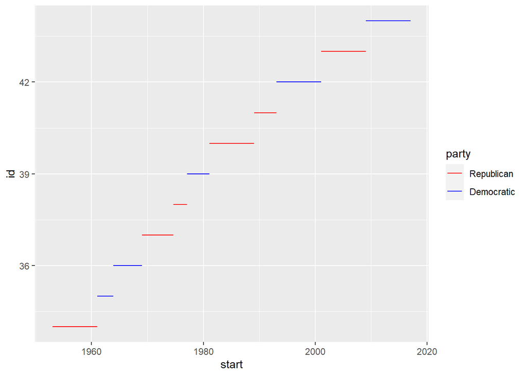

```r
presidential %>%
  mutate(id = 33 + row_number()) %>%
  ggplot(aes(start, id, colour = party)) +
    geom_segment(aes(xend = end, yend = id)) +
    scale_colour_manual(values = c(Republican = "red", Democratic = "blue"))
```

#### Label and Annotation

- **Labels** control plot title, plot caption, and axes names
- **Annotations** place text on the plot that describes the visual object

| Function | Use |
| --- | --- |
| `lab()` | Place labels on title, plot, caption, and axes names |
| `geom_text()` | Visual object made of text |
| `geom_label()` | Visual object made of text with rectangle behind it to increase visibility |
| `ggrepel::geom_label_repel()` | Same as `geom_label()`, but package function has rectangles “repel” each other so they do not overlap |
| `annotate()` | Visual object made of text that is not attached to specific data points |

**lab()**

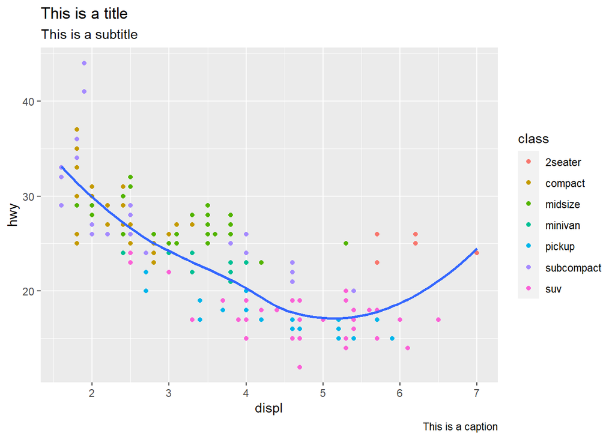

```r
ggplot(data = mpg, mapping = aes(displ, hwy)) +
  geom_point(mapping = aes(color = class)) +
  geom_smooth(se = FALSE) +
  labs(
    title = "This is a title",
    subtitle = "This is a subtitle",
    caption = "This is a caption"
  )
```

**Change Axis Names**

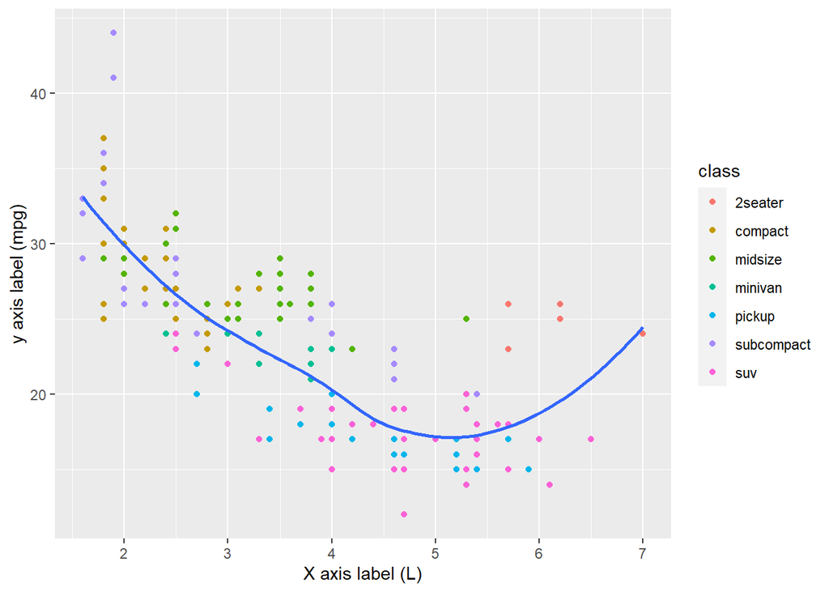

```r
ggplot(data = mpg, mapping = aes(displ, hwy)) +
  geom_point(mapping = aes(color = class)) +
  geom_smooth(se = FALSE) +
  labs(
    x = "X axis label (L)",
    y = "y axis label (mpg)"
  )
```

**geom_text()**

```r
# Find most fuel efficient model of car in class
best_in_class <- mpg %>%
  group_by(class) %>%
  filter(row_number(desc(hwy)) == 1)

best_in_class
```

```
#> # A tibble: 7 x 11
#> # Groups:   class [7]
#>   manufacturer model     displ  year   cyl trans  drv     cty   hwy fl    class
#>   <chr>        <chr>     <dbl> <int> <int> <chr>  <chr> <int> <int> <chr> <chr>
#> 1 chevrolet    corvette    5.7  1999     8 manua~ r        16    26 p     2seat~
#> 2 dodge        caravan ~   2.4  1999     4 auto(~ f        18    24 r     miniv~
#> 3 nissan       altima      2.5  2008     4 manua~ f        23    32 r     midsi~
#> 4 subaru       forester~   2.5  2008     4 manua~ 4        20    27 r     suv
#> 5 toyota       toyota t~   2.7  2008     4 manua~ 4        17    22 r     pickup
#> 6 volkswagen   jetta       1.9  1999     4 manua~ f        33    44 d     compa~
#> 7 volkswagen   new beet~   1.9  1999     4 manua~ f        35    44 d     subco~
```

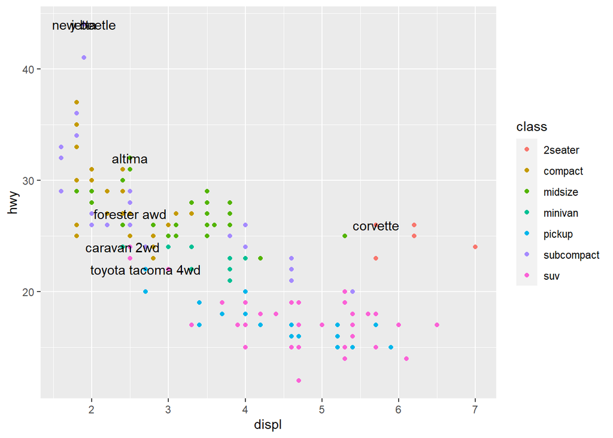

```r
# Plot and Annotate
ggplot(mpg, aes(displ, hwy)) +
  geom_point(aes(color = class)) +
  geom_text(aes(label = model), data = best_in_class)
```

**geom_label()**

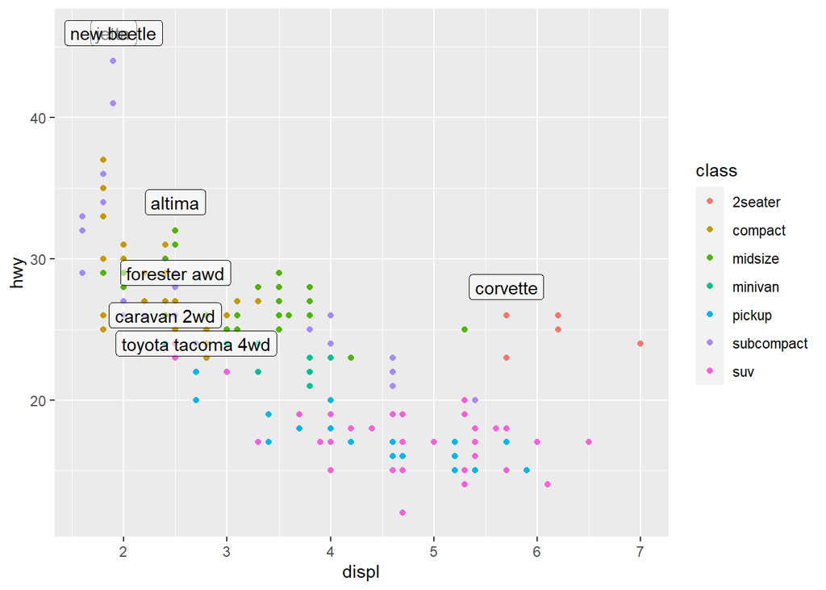

```r
best_in_class <- mpg %>%
  group_by(class) %>%
  filter(row_number(desc(hwy)) == 1)

ggplot(mpg, aes(displ, hwy)) +
  geom_point(aes(color = class)) +
  geom_label(aes(label = model), data = best_in_class, nudge_y = 2, alpha = 0.5)
```

**ggrepel::geom_label_repel()**

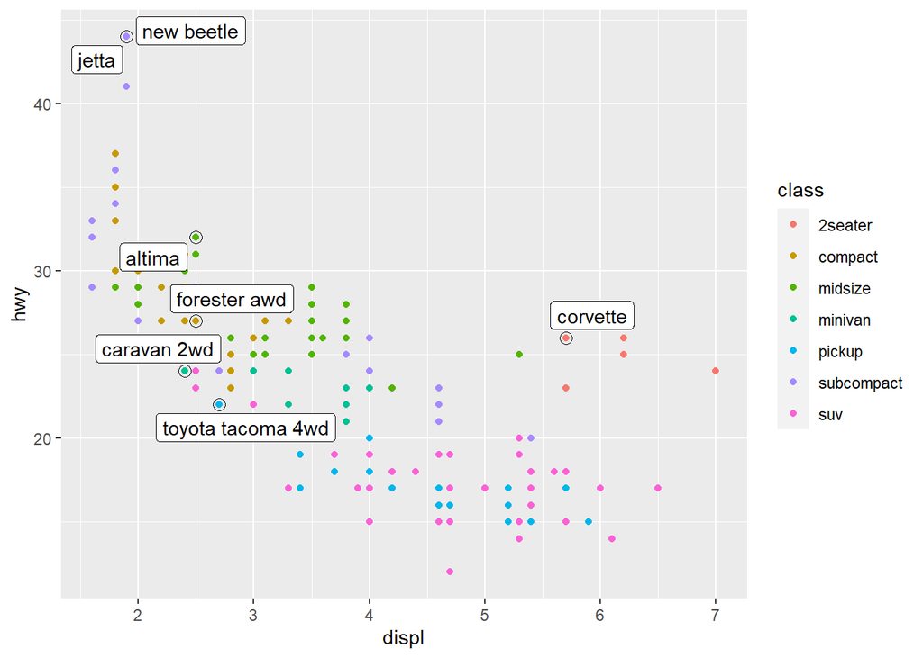

```r
best_in_class <- mpg %>%
  group_by(class) %>%
  filter(row_number(desc(hwy)) == 1)

# The extra point geom makes the points stand out more
ggplot(mpg, aes(displ, hwy)) +
  geom_point(aes(color = class)) +
  geom_point(size = 3, shape = 1, data = best_in_class) +
  ggrepel::geom_label_repel(aes(label = model), data = best_in_class)
```

**annotate()**

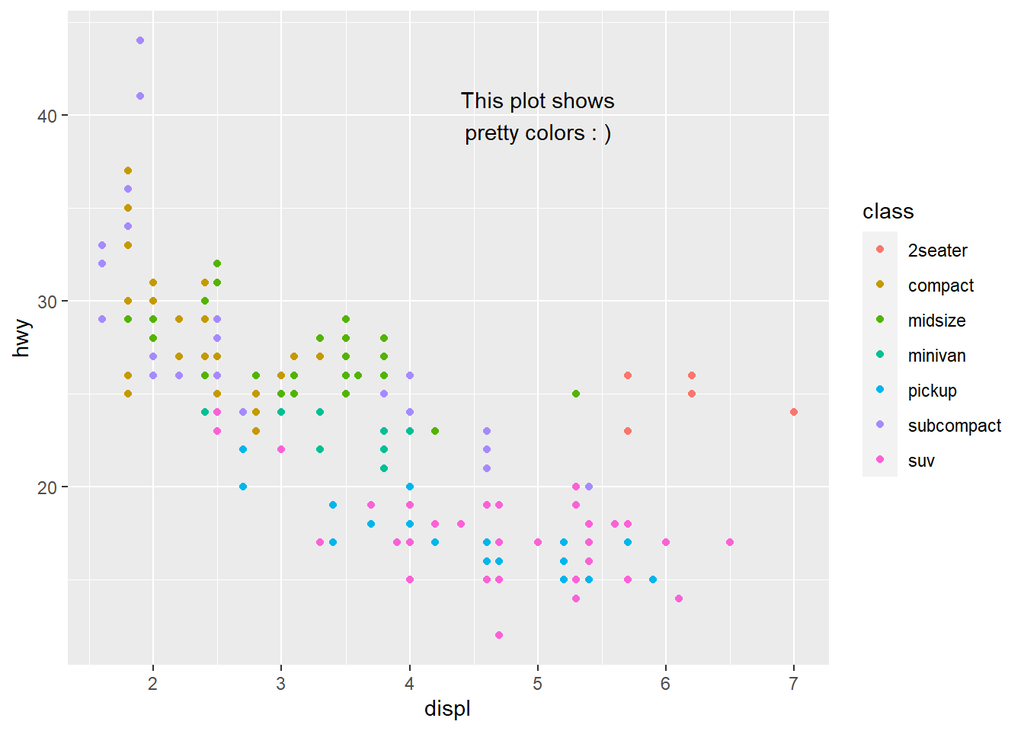

```r
ggplot(mpg, aes(displ, hwy)) +
  geom_point(aes(color = class)) +
  annotate(
      geom = "text",
    x = 5,
    y = 40,
    label = "This plot shows\npretty colors : )"
  )
```

```r
0
```

```
#> [1] 0
```

#### Theme

ggplot2 uses the grey theme by default, but includes 8 total. Many more can be downloaded in packages like ggthemes.

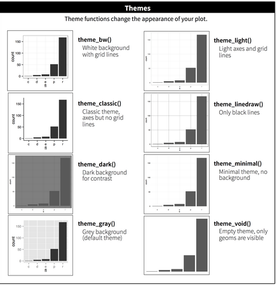

```r
ggplot(mpg, aes(displ, hwy)) +
  geom_point()
```

[output not shown]

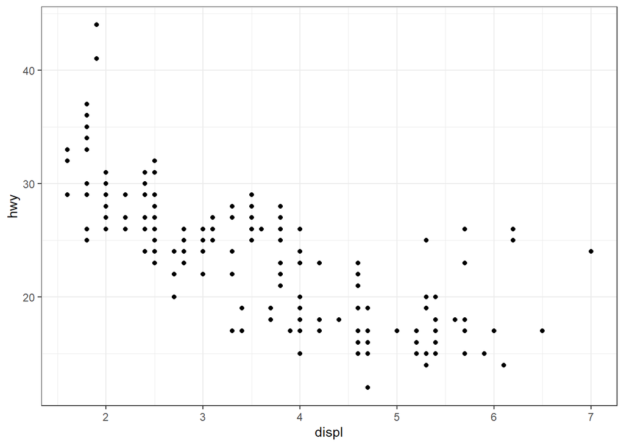

```r
ggplot(mpg, aes(displ, hwy)) +
  geom_point() +
  theme_bw()
```

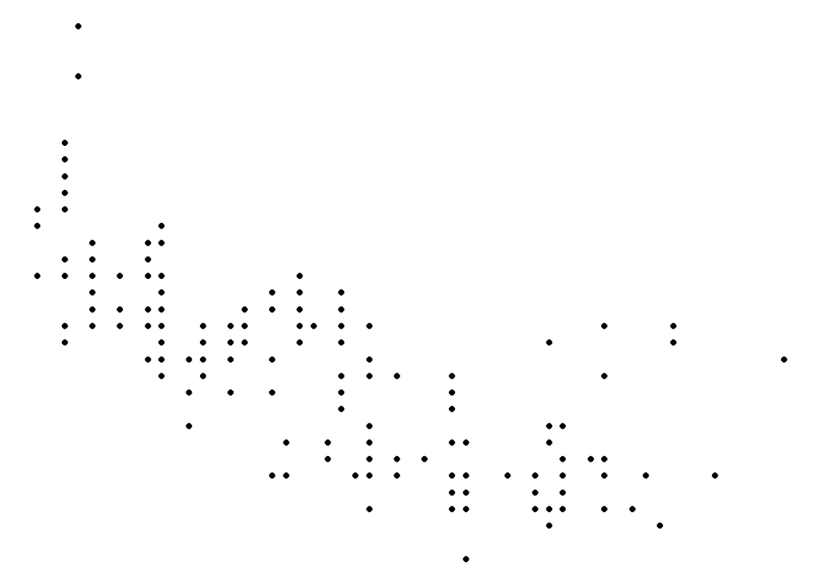

```r
ggplot(mpg, aes(displ, hwy)) +
  geom_point() +
  theme_void()
```

#### Saving Plots

There are two main ways of saving plots:

1. `ggsave()` saves the most recent plot as a PDF. You must specify the file name. Optionally, you can specify image size, file path, and file type. This is good if you only want to share a single image file.
2. Create plots in code chunks in R Markdown and output that document as a PDF or HTML file. This is recommended as you can share code input as well as any descriptive text. We’ll cover code chunk options in the *Communicate* section of *Data Science*.

**ggsave()**

```r
ggplot(mpg, aes(displ, hwy)) +
  geom_point()
```

[output not shown]

```r
ggsave("output/plot_ex.pdf")
```

## Model

- **Model** is a broad term applied to fashion, cars, informative sculptures, machine learning, and more. Here, we’ll focus on the simplest regression models, which are conveniently coined **simple linear regression** models. The focus will not be on the statistical methods involved, but instead on the broader idea of using models in the data science workflow.

### Simple Linear Regression

- **Simple Linear Regression** models the relationship between two continuous numerical variables using a straight line function
- The words *function* and *model* can be used interchangeably in this case
- A **function** is an equation where each x has only one y (passes vertical line test)
- Simple linear regression uses a straight line function in the form of $y = mx + b$, though in statistics this is usually written as $y = \beta_0 + \beta_1x$
- The “regression” part refers to finding the function with the least error, AKA “best fit”. The term regression does not really mean anything mathematically and is more of a historical quirk.
- **x**. Often, there is a variable(s) whose values are already known or can be easily measured. We call this variable x. Sometimes x affects other variables, so we call x the **independent/predictor/explanatory** variable.
- **y**. Often, there is a variable whose values are hard to directly measure and/or are important to predict, and we want to know why the values change. We call this variable y. If the value of y depends on any other variable it is called a **dependent/response/outcome** variable. If y changes *because* x changes then this is **causation**. If y changes along with x, but NOT NECESSARILY because of x, then this is **correlation**

### Residuals and Best Fit

The model with the **best fit** has the least amount of error. This does not mean the model is accurate. It means it is the best representation of the data generated so far. Error is measured by the **residual**.

- $\text{residual} = \text{actual outcome} - \text{predicted outcome}$
- $\text{residual} = y - \hat{y}$
- Residuals can be negative or positive

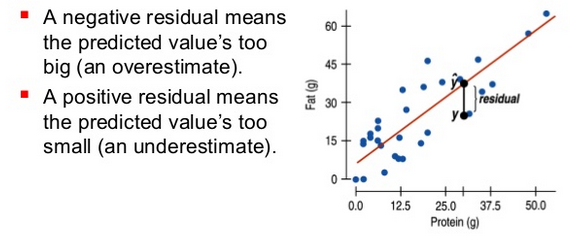

Two popular statistics that use the residual are RMSE and MAE:

1. **RMSE** stands for root mean squared error
   - $\text{RMSE} = \sqrt{\frac{\sum_{i=1}^{n}(y_i - \hat{y_i})^2}{n}}$
   - Due to the initial squaring operation, very small residuals (between 0 and 1) become even smaller, and larger residuals become even larger. This is good if you believe that larger errors are more important and should be weighted more.
2. **MAE** stands for mean absolute error
   - $\text{MAE} = \frac{\sum_{i=1}^{n}|y_i - \hat{y_i}|}{n}$
   - MAE weights every unit of error equally

Here are a few reminders when using RMSE and MAE:

- When comparing different models using error statistics, the statistic must be the same
  - E.g. don’t compare RMSE from one model to the MAE of another model
- When comparing RMSE to RMSE or MAE to MAE, the variables in both models must use the same units
  - E.g. if distance is measured in feet in one model, it must be measured in feet in the other model
- Be careful to avoid overfitting the model, especially if using a small sample size. **Overfitting** is the use of more coefficients in a function so that the line is tailored to that data. This minimizes error for the current dataset, but may increase error for new data. I.e. *K.I.S.S.*. This is irrelevant for simple linear regression.

### Training and Testing

When you create a model you feed it pairs of x and y data. These data points are called **observations.** The creation of the model is called **training**, as creation is usually iterative and improves over time. A computer program/algorithm tries a function, calculates error, adjusts function, calculates error, etc., until the function with the least error is found.

If you just want to describe the historical relationship between x and y then you could use all your observations in training. However, most of the time we want to be able to predict y from x in the future. **Testing** is the statistical assessment of a models accuracy with new input data.

There are two rules for testing and training:

1. Each observation can either be used to train the model or test the accuracy of model, but NOT both
2. You can use an observation as many times as you like for training, but can only use it once when testing the model. As soon as you start using an observation multiple times for “testing” (after which you adjust model) you are essentially using it for “training”.

For these reasons often times about 60% of data goes into training, 20% goes into a **query** set for manual human data exploration/model tweaking, and 20% is held back for testing the model(s) generated.

### modelr Package

- The modelr package contains tools for making basic models…r
- Allows data to be easily used with pipe operator
- It is not part of the core tidyverse so it must be imported separately
- It is primarily used to teach students modeling
- The tidymodels package is used for research

| Function | Use |
| --- | --- |
| `sim1` | Simulated dataset |
| `sim2` | Simulated dataset |
| `sim3` | Simulated dataset |
| `sim4` | Simulated dataset |
| `runif()` | Returns vector of **r**andomly generated values within specified range. Uses **unif**orm distribution. |
| `optim()` | Find best fitting function. Actually in stats package in System Library (built-in). |
| `lm()` | Find best fitting linear function. Actually in stats package in System Library (built-in). |
| `data_grid()` | Returns DF column of unique, evenly spaced x values from dataset. Evenly spaced x values can help visualize a model using a plot. |
| `add_predictions()` | Returns DF column of predicted y values given a DF column of x values and a model |
| `add_residuals()` | Returns DF column of residual values given x values, actual y values, and a model |
| `options(na.action = na.warn)` | When argument is run in the “prerequisites” of a function, it makes sure R gives you warning when a NA value is dropped |
| `model_matrix()` | Returns tibble that defines the model equation. Each column in the tibble is associated with one variable in the model. |

#### Manually Find Best Fit

Plotting the `sim1` dataset shows a linear relationship between x and y. We’ll find the linear model of best fit for the sim1 dataset manually by:

1. Creating 500 lines with random slopes and intercepts
2. Defining a generic line function
3. Defining a RMSE function
4. Defining a RMSE specifically for the sim1 DF
5. Calculating RMSE for all 500 random lines and returning this info in a DF
6. Sorting and filtering this DF to show 10 best fitting lines
7. Plotting best fitting lines

**sim1 Plot**

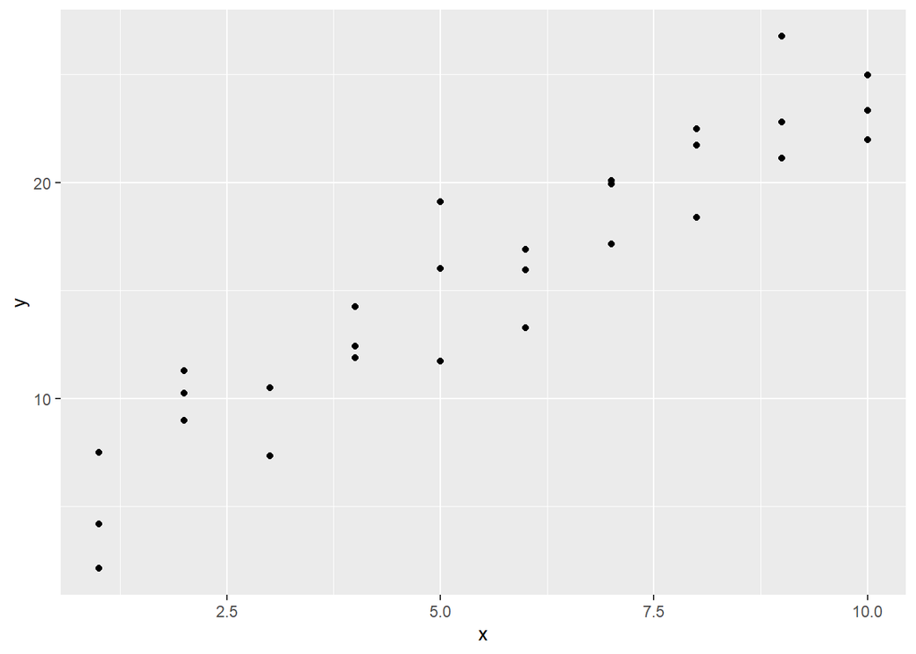

```r
ggplot(sim1, aes(x = x, y = y)) +
  geom_point()
```

**Randomly Generate Linear Models**

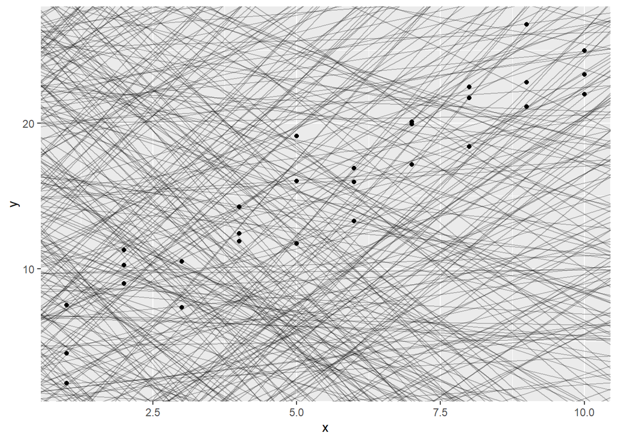

```r
rand_slopes_intercepts <- tibble(
  rand_slopes = runif(500, -5, 5),
  # Generates 500 random numbers between -5 and 5 in vector
  # Assumes uniform distribution (constant probability across range)
  # Used for slope
  rand_intercepts = runif(500, -20, 40),
  # Generate 500 random numbers between -20 and 40 in vector
  # Used for intercept
)

# Plot liner models
ggplot(sim1, aes(x = x, y = y)) +
  # abline takes in vectors of intercepts and slopes and plots lines
  # We specify the correct df columns and the DF
  geom_abline(
    aes(intercept = rand_intercepts, slope = rand_slopes),
              data = rand_slopes_intercepts, alpha = 1/4
    ) +
  # alpha changes line transparency
  geom_point()
```

**Linear Function Function**

We create a formula for a line function and save it as an R function. This allows us to generate the predicted outcomes from the x values

```r
# Create a function that takes in a  DF, slope, and intercept
my_pred_out <- function(df, slope, intercept) {
  slope * df$x + intercept
}

# Vector of predicted outputs example
my_pred_out(sim1, 1.5, 7)
```

```
#>  [1]  8.5  8.5  8.5 10.0 10.0 10.0 11.5 11.5 11.5 13.0 13.0 13.0 14.5 14.5 14.5
#> [16] 16.0 16.0 16.0 17.5 17.5 17.5 19.0 19.0 19.0 20.5 20.5 20.5 22.0 22.0 22.0
```

**Create Our Own RMSE Function**

```r
my_RMSE <- function(df, slope, intercept) {
  # vector of errors = vector of actual - vector of predicted
  errors <- df$y - my_pred_out(df, slope, intercept)
  # Square each value in the vector, then calculate mean, then square root
  sqrt(mean(errors^2))
}

# Returns RMSE for an example line with a slope of 1.5 and an intercept of 7
my_RMSE(sim1, 1.5, 7)
```

```
#> [1] 2.665212
```

**Calculating RMSE for our Random Linear Models with sim1 DF**

```r
# RMSE just for Sim1 DF, so only arguments are slope and intercept
sim1_RMSE <- function(slope, intercept) {
  my_RMSE(sim1, slope, intercept)
}

# Assign output to new tibble
# Pipe in randomly created slopes and intercepts from other tibble
# Create new column in tibble, name column "col_RMSE"
# Use each pair of random slopes and intercepts in sim1_RMSE function
# Generate tibble of RMSE values for all the random lines formed
sim1_rand_RMSE <- rand_slopes_intercepts %>%
  mutate(col_RMSE = purrr::map2_dbl(rand_slopes, rand_intercepts, sim1_RMSE))
sim1_rand_RMSE
```

```
#> # A tibble: 500 x 3
#>    rand_slopes rand_intercepts col_RMSE
#>          <dbl>           <dbl>    <dbl>
#>  1     -4.07             5.91     36.6
#>  2     -4.99             2.08     45.7
#>  3     -0.957           -1.13     23.6
#>  4     -0.0635           6.79     11.1
#>  5     -3.20            34.3      15.3
#>  6      0.983          -12.0      22.4
#>  7      2.94            -0.949     3.34
#>  8      0.239           14.7       5.64
#>  9     -0.780           16.3       9.09
#> 10      4.25            38.4      46.7
#> # ... with 490 more rows
```

**Plot Best 10 Models**

```r
# Sort rows based on col_RMSE
# Smallest RMSE on top
top_10_models <- arrange(sim1_rand_RMSE, col_RMSE) %>%
  # Only include a record if its value in col_RMSE
  # is in the first 10  rows (the lowest)
  filter(col_RMSE %in% head(col_RMSE, 10))
top_10_models
```

```
#> # A tibble: 10 x 3
#>    rand_slopes rand_intercepts col_RMSE
#>          <dbl>           <dbl>    <dbl>
#>  1        2.10           5.12      2.44
#>  2        1.67           5.69      2.47
#>  3        2.18           5.66      3.06
#>  4        2.34           4.90      3.22
#>  5        2.94          -0.949     3.34
#>  6        2.32           0.232     3.39
#>  7        1.11           9.64      3.45
#>  8        3.02          -0.906     3.51
#>  9        2.75          -1.77      3.63
#> 10        1.11          10.9       3.76
```

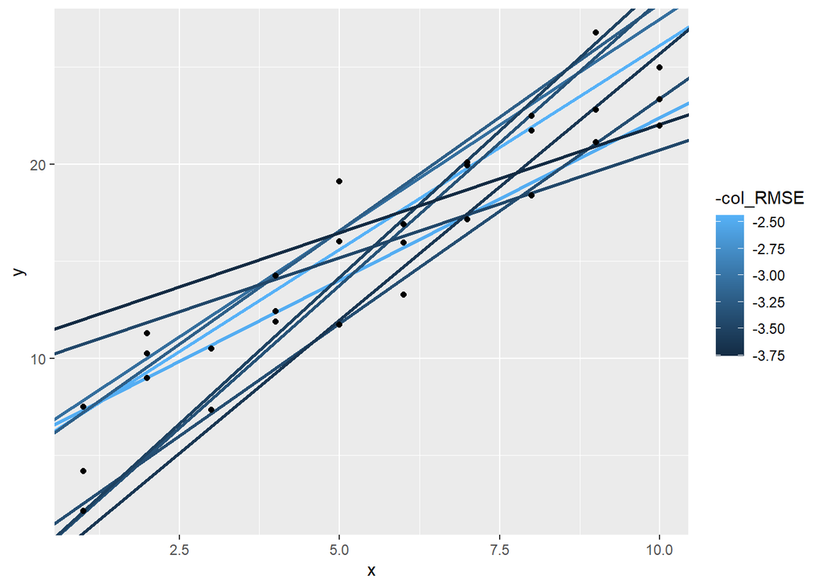

```r
# Plot top 10 models
ggplot() +
  geom_abline(
    aes(intercept = rand_intercepts, slope = rand_slopes, color = -col_RMSE),
    data = top_10_models,
    size = 1
    ) +
  geom_point(data = sim1, mapping = aes(x = x, y = y))
```

#### optim() Function

`optim()` uses various algorithms to narrow down and select the model that has the best fit. It does this by iteratively calculating the error, modifying model parameters, calculating error, etc. You supply:

1. A vector of starting parameters. We’ll tell `optim()` to start with a slope of 0 and an intercept of 0.
2. A function that defines the error. The first parameter of the error function must be a vector of parameters for the model that `optim()` can modify. Here, parameters are slope (`params[1]`) and intercept (`params[2]`). `optim()` modifies the slope and intercept until it finds the model that gives the lowest output in the error function.
3. The dataset. The variable name (here df), must match the variable name in the error function and line function.

**optim() with RMSE**

```r
# Rewrite our functions
# 1st parameter must be vector that opim() can change
# Otherwise optim() returns an error

# Define Line Function
# We'll put it in mx+b form
my_line_2 <- function(params, df) {
  params[1] * df$x + params[2]
}

# Define RMSE Function
my_RMSE_2 <- function(params, df) {
  errors <- df$y - my_line_2(params, df)
  sqrt(mean(errors^2))
}

# Use optim()
best <- optim(c(0, 0), my_RMSE_2, df = sim1)

str_c("You can see that the best fitting line had a slope of ", best$par[1], ", and a y-intercept of ", best$par[2], ".  This is similar to the best fitting line chosen from 500 random slopes + intecepts above.",  sep = "" )
```

```
#> [1] "You can see that the best fitting line had a slope of 2.05120381317836, and a y-intercept of 4.22224779961461.  This is similar to the best fitting line chosen from 500 random slopes + intecepts above."
```

**optim() with MAE**

We could also use MAE in our `optim()` function if we wanted to place equal weight on all errors

```r
my_line_2 <- function(params, df) {
  params[1] * df$x + params[2]
}

# Define MAE Function
my_MAE <- function(params, df) {
  errors <- df$y - my_line_2(params, df)
  mean(abs(errors))
}

# Use optim()
best_MAE <- optim(c(0, 0), my_MAE, df = sim1)
str_c("With MAE the best fitting line had a slope of ", best_MAE$par[1], ", and a y-intercept of ", best_MAE$par[2],  sep = "" )
```

```
#> [1] "With MAE the best fitting line had a slope of 2.04891753473623, and a y-intercept of 4.36485242412701"
```

#### lm() Function

- `lm()` uses a different algorithm than `opim()`
- It can actually find the closest model in a single step
- However, `lm()` only works on general linear models in the form of: `y = a_0 + a_1 * x_1 + a_2 * x_2 + ...`

```r
sim1_mod <- lm(y ~ x, data = sim1)
coef(sim1_mod)
```

```
#> (Intercept)           x
#>    4.220822    2.051533
```

- Notice `lm()` and `optim()` have found very very similar slopes and intercepts

#### Residuals

**Find Residuals of Best Model**

```r
# Find and assign name to best fitting model
sim1_mod <- lm(y ~ x, data = sim1)

# Find residuals of model
sim1_resid <- sim1 %>%
  add_residuals(sim1_mod)
sim1_resid
```

```
#> # A tibble: 30 x 3
#>        x     y    resid
#>    <int> <dbl>    <dbl>
#>  1     1  4.20 -2.07
#>  2     1  7.51  1.24
#>  3     1  2.13 -4.15
#>  4     2  8.99  0.665
#>  5     2 10.2   1.92
#>  6     2 11.3   2.97
#>  7     3  7.36 -3.02
#>  8     3 10.5   0.130
#>  9     3 10.5   0.136
#> 10     4 12.4   0.00763
#> # ... with 20 more rows
```

**Graph Residuals of Best Model**

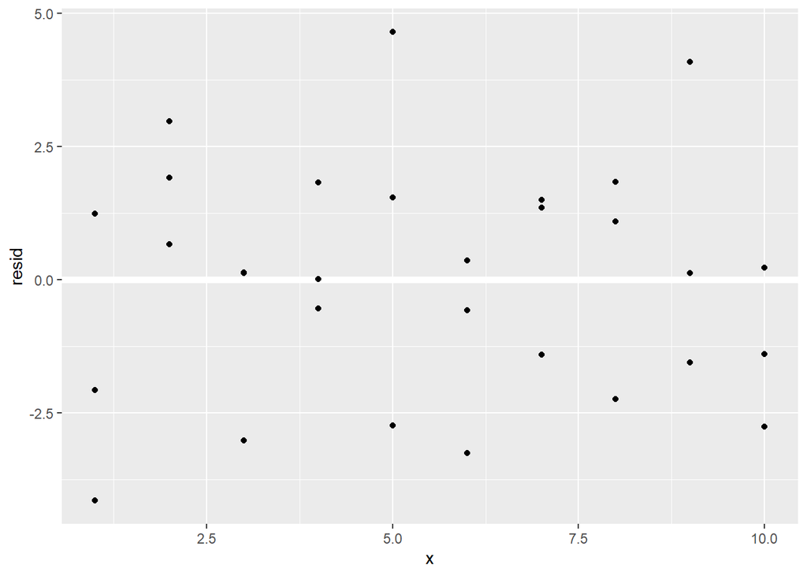

```r
ggplot(data = sim1_resid, mapping = aes(x = x, y = resid)) +
  geom_ref_line(h = 0) +
  geom_point()
```

**Graph Residual Frequency of Best Model**

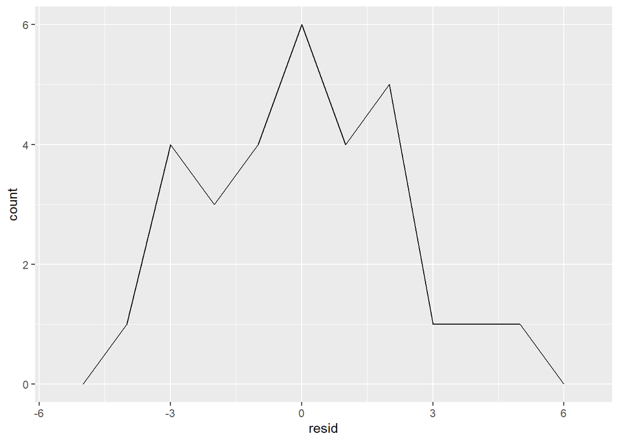

```r
ggplot(data = sim1_resid) +
  geom_freqpoly(
    mapping = aes(x = resid),
    binwidth = 1
)
```

#### Graph Any Model

- Plot our best fitting model
- Use `data_grid(x)` to return DF column of unique, evenly spaced x values from specified dataset
- Use `add_predictions()` to return calculated predicted values from our model and x values
- Using similar methods allows us to plot any model in R, not just straight lines

```r
# Find and assign name to best fitting model
sim1_mod <- lm(y ~ x, data = sim1)

# Find unique x values in dataset
grid <- sim1 %>%
  data_grid(x)
grid
```

```
#> # A tibble: 10 x 1
#>        x
#>    <int>
#>  1     1
#>  2     2
#>  3     3
#>  4     4
#>  5     5
#>  6     6
#>  7     7
#>  8     8
#>  9     9
#> 10    10
```

```r
# Match unique x values with corresponding predicted y values
grid <- grid %>%
  add_predictions(sim1_mod)
grid
```

```
#> # A tibble: 10 x 2
#>        x  pred
#>    <int> <dbl>
#>  1     1  6.27
#>  2     2  8.32
#>  3     3 10.4
#>  4     4 12.4
#>  5     5 14.5
#>  6     6 16.5
#>  7     7 18.6
#>  8     8 20.6
#>  9     9 22.7
#> 10    10 24.7
```

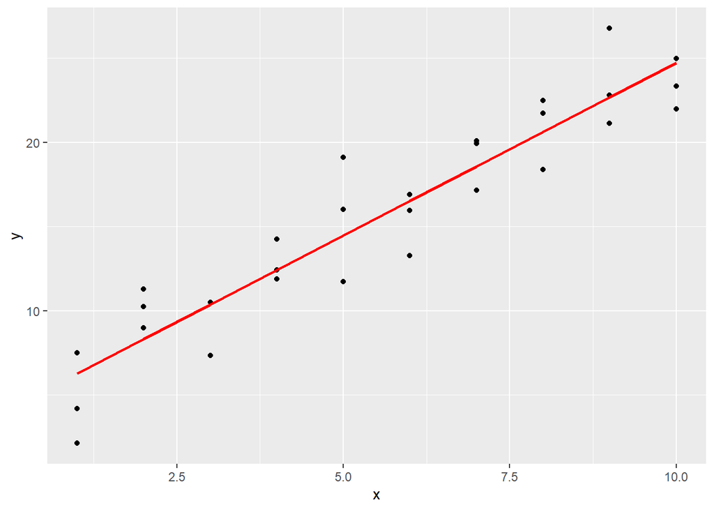

```r
ggplot(data = sim1, aes(x = x)) +
  geom_point(aes(y = y)) +
  geom_line(aes(y = pred), data = grid, color = "red", size = 1)
```

#### Formulas

- “formulas” are designated with the `~` symbol
- `~` indicates some sort of special meaning/behavior
- R formulas do not have the same meaning as a mathematical formula
- We saw `~` in `tribble()`, `facet_wrap()`, `facet_grid()`, and `lm()`
- R uses `~` in linear models with Wilkinson-Rogers Notation
- **Wilkinson-Rogers Notation** is a shorthand notation used to write out the structure of linear models. The `~` can be read “is modeled as a function of”
- Frankly, seems like a pain to use and I don’t fully understand the notation yet
- In the table below each x sub number is a different predictor variable

| Predictor | Wilkinson-Rogers Notation |
| --- | --- |
| Y Intercept | 1 (Default) |
| No Y Intercept | -1 |
| $x_1$ | x1 |
| $x_1$, $x_2$ | x1 + x2 |
| $x_1$, $x_2$, $x_1$$x_2$ | x1*x2 |
| $x_1$$x_2$ | x1:x2 |
| $x_1^{2}$ | x1^2-x1 |
| $x_1$ + $x_2$ | I(x1 + x2) |

- In the “model” column below, the $\beta$ is a coefficient like how `m` and `b`are coefficients in `y = mx + b`
- R by default includes a y-intercept term, so if you don’t want it you need to indicate that with a `-1`
- $\epsilon$ is some sort of optional random variation term?

| Model | Wilkinson-Rogers Notation |
| --- | --- |
| $y = \beta_1x_1 + \epsilon$ | y ~ -1 + x1 |
| $y = \beta_0 + \beta_1x_1 + \epsilon$ | y ~ x1 |
| $y = \beta_0 + \beta_1x_1 + \beta_2x_2 + \epsilon$ | y ~ x1 + x2 |

**model_matrix()**

- To view the variables indicated by the Wilkinson-Rogers Notation you can use `model_matrix()`. It returns a tibble with each column associated with variables and the slope intercept

```r
df <- tribble(
  ~y, ~x1, ~x2,
  4, 2, 5,
  5, 1, 6
)

# Use -1 if don't want y intercept column
model_matrix(df, y ~ -1 + x1)
```

```
#> # A tibble: 2 x 1
#>      x1
#>   <dbl>
#> 1     2
#> 2     1
```

```r
# Includes y intercept with values of 1 by default
model_matrix(df, y ~ x1)
```

```
#> # A tibble: 2 x 2
#>   `(Intercept)`    x1
#>           <dbl> <dbl>
#> 1             1     2
#> 2             1     1
```

```r
model_matrix(df, y ~ x1 + x2)
```

```
#> # A tibble: 2 x 3
#>   `(Intercept)`    x1    x2
#>           <dbl> <dbl> <dbl>
#> 1             1     2     5
#> 2             1     1     6
```

### tidymodels Package

- The tidymodels umbrella package contains tools for modeling
- Contains rsample, parsnip, recipes, workflows, tune, yardstick, broom, and dials packages

## Communicate

There are a variety of packages that can help you format data, share data, and build interactivity. For example, you may see the buttons in RStudio for shiny, which is a package that helps you build interactive web apps that use R code. There is also Bookdown, which is a package that contains tools for converting an R Markdown document into a fully functional ebook. We’ll focus on two topics:

1. Formatting an R Markdown document with the knitr package
2. Data sharing and version control with Git and GitHub

### knitr Package

- Check out their [website](https://yihui.org/knitr/). Great reference document of all options.
- The knitr package contains tools to change the output of your code chunks…r

| Function | Use |
| --- | --- |
| `knitr::opts_chunk$set()` | Set code chunk options for entire document |
| `knitr::kable()` | Create pretty table |
| `{r <PLOT OPTIONS>}` | Change plot size and other plot options |

#### Chunk Set

The `knitr::opts_chunk$set()` function is placed near the beginning of the R Markdown document. It controls options for code chunks that follow. The table pictured below show some of the options you can control. Not shown in the picture below are `collapse` and `comment`. `collapse` merges the code input and code output boxes. `comment` changes the symbol that is placed at the start of each line of code output. To see all the chunk options, check out the R Markdown cheat sheet and R Markdown reference sheet.

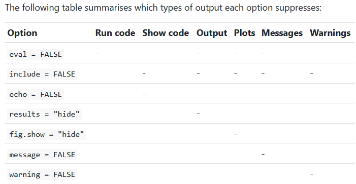

This is the code placed at the beginning of this R Markdown document:

```
knitr::opts_chunk$set(
  message = FALSE,
  warning = FALSE,
  collapse = FALSE,
  comment = "#>"
)
```

#### Pretty Table

**knitr::kable()**

```r
knitr::kable(
  starwars[1:5, 1:5],
  caption = "Star Wars Characters"
)
```

Star Wars Characters

| name | height | mass | hair_color | skin_color |
| --- | --- | --- | --- | --- |
| Luke Skywalker | 172 | 77 | blond | fair |
| C-3PO | 167 | 75 | NA | gold |
| R2-D2 | 96 | 32 | NA | white, blue |
| Darth Vader | 202 | 136 | none | white |
| Leia Organa | 150 | 49 | brown | light |

#### Plot Options

In a code chunk, you can use the space within curly brackets after the `r` in `{r}` to change plot output options. Five main options control figure sizing. You only need to use three out of the five. Usually figure width, figure aspect, and output width will do. *R for Data Science* offers suggestions for plot sizes, but these may not be the best options for all plots.

| Option | Use |
| --- | --- |
| `fig.width` | Controls plot width in RStudio. Number is inches. `fig.width = 6` suggested. |
| `fig.height` | Controls plot height in RStudio |
| `fig.asp` | Controls aspect ratio. `fig.asp = 0.618` suggested. Golden ratio. |
| `out.width` | Controls width of plot in output document. The percentage is NOT a percentage of the `fig.width`. It is a percentage of the width of the output document. `out.width = "70%"` suggested. |
| `out.height` | Controls height in output document |
| `fig.align` | Controls plot alignment in output document. `fig.align = "center"` suggested. |
| `fig.show` | Controls if plot is shown immediately after code or at the end of the entire code chunk in the output document. `fig.show = "hold"` suggested so that plot is inserted after entire code chunk. |
| `fig.cap` | Adds caption |
| `dev` | If your document output is a PDF and you want to save space, then use `dev = "png"` to save plot as .png file |

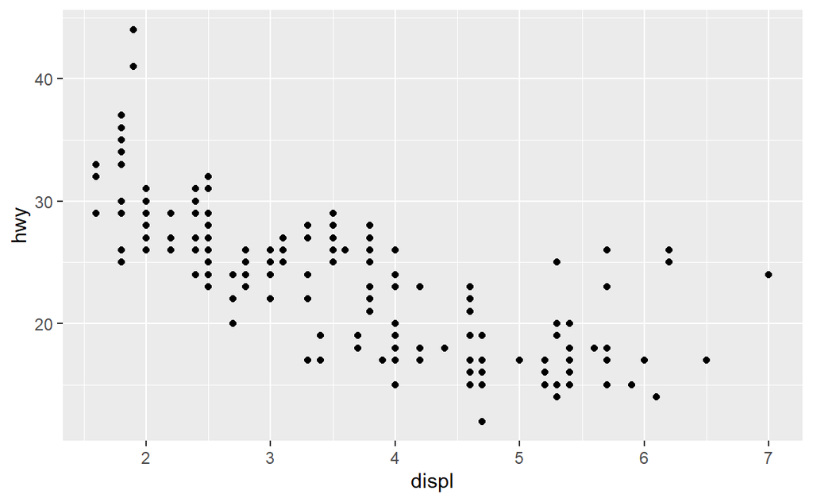

Caption

```r
ggplot(mpg, aes(displ, hwy)) +
  geom_point()
```

### Git and GitHub

#### Git

- **Git** is an open source, decentralized, version control system created in 2005 by Linus Torvalds. He also helped create Linux.
- Git tracks changes to folders and files. It allows users to see the who, what, where, when, and why of every edit.
- Git commands are used with a Command Line Interface (CLI) to manage and edit project files. On Windows, you should use the Bash Shell that comes with Git for Windows as opposed to the Command Prompt.
- **Git Clients** provide a GUI for Git. Allows better visualization of edit history, though some prefer to exclusively use the CLI. There are many Git clients including GitHub Desktop, GitKraken, SourceTree, and TortoiseGit. Code editors like Atom, VS Code, and RStudio also work well with Git.
- The RStudio GUI can be used so that all or most Git commands are not needed

#### GitHub

- **GitHub** is a social user interface and cloud storage platform built upon Git
- Used to share, edit, and collaborate on projects. It is used mostly for collaborating on coding projects that use plain text files.
- Uses GitHub Flavored [[Markdown]]
- GitHub becomes very useful when multiple people are editing the same files. They can even do so at the same time!
- If you are the only one using your files and you simply want your files available to you across multiple computers, then another cloud storage service like Dropbox, Google Drive, Microsoft OneDrive, etc., will be easier to use.

#### Git and GitHub Resources

There are many resources to help learn Git, GitHub, and their integration with RStudio. I’d explore the following resources in the order listed:

1. [Fist Day on GitHub](https://lab.github.com/githubtraining/first-day-on-github)—five part beginner GitHub tutorial. Includes:
   1. *What is GitHub?*—intro video
   2. *Introduction to GitHub*—interactive tutorial using repository. You create and edit a GitHub repository, which ends up becoming your user profile page.
   3. *Git Handbook*—web page covers common Git commands that are used in the command line interface
   4. *Communicate using Markdown*—interactive tutorial for using Markdown syntax
   5. *Updating your project to GitHub*—interactive tutorial where you upload a file on your computer to a GitHub repository. I would use the *happygitwithr* instructions below to help install Git on your computer before doing this GitHub tutorial. The tutorial did not work for me. The `git push` command made the Git Bash shell go to the next blank line but performed no actions. I had to type `Ctrl-c` to exit the stuck command. I believe this had something to do with HTTPS not requesting my password information when it should have. Worked with Git Bash terminal within VS Code.
2. [happygitwithr](https://happygitwithr.com/)—instructions for using Git and GitHub with RStudio. Will answer any questions you have when installing Git. After completing GitHub tutorials, watch the following RStudio webinar. Then come back to the later sections in this text to practice workflows with RStudio.
3. [RStudio Webinar](https://www.rstudio.com/resources/webinars/managing-part-2-github-and-rstudio/)—webinar from RStudio that explains using Git and Github with RStudio. Good for visualizing workflow.
4. [R Package](https://r-pkgs.org/git.html)—more advanced tips for using Git and GitHub with RStudio
5. [Pro Git Book](http://git-scm.com/book/en/v2)—online book on all things Git
6. [GitHub Docs](https://docs.github.com/en/github)—a collection of GitHub help documents